# Final Project Proposal: COVID-19 Dataset

Due Friday, October 9, 11:59 PM

The Lads: Frankie Willard, Manny Mokel, Alex Katopodis, Parker Dingman

### Section 1- Introduction

Throughout the year 2020, the COVID-19 pandemic took the world by storm, deeply impacting every country on the planet, albeit with differing degrees of severity. As cases continued to rise, families suffered from the loss of family members, jobs, social interactions, disposable income, and more. This public health crisis became severe enough such that many countries took decisive action, shutting down their economies to prioritize the lives of the citizens of their country. Meanwhile, other countries were less strict in their policies, attempting to preserve their economy at the potential expense of their citizen’s lives. The difference in each country’s characteristics, demographics, public health capacities, and the strictness of COVID-19 policies led to vastly different effects of the pandemic on different countries. Given our personal connections to the effects of the pandemic through our lives, our friends, and our families, we wanted to determine what led to the pandemic affecting some places worse than others.  
For our final project, we will be investigating country-level COVID-19 data to determine the relationship between their characteristics and demographics to virus transmission and deaths. By analyzing the effects of different country characteristics, we seek to determine specifically which variables are associated with stringency indexes, cases per capita, and deaths per case.

Research Question:

How do a country’s characteristics, geography, and demographics impact the strictness of their COVID policy, as well as the total spread and effects of COVID-19?

Hypotheses:

We hypothesize that cases per capita will have a strong negative correlation to stringency index.

We hypothesize that deaths per case will be largely determined by the GDP per capita, the number of citizens aged 65+, hospital beds per thousand, the human development index, and columns concerning pre-existing conditions (i.e. diabetes prevalence, cardiovascular death rate, etc).

We hypothesize that the stringency index is going to vary the most by continent. We expect Europe, Asia, Oceania, and North America to have higher stringency indexes, while Africa and South America will have lower stringency indexes.

### Section 2- Data description

We selected a data set from Our World in Data. Each observation in the data set shows relevant COVID-19 data for a particular country on a given date. The COVID-19 data in the data set includes total deaths, total cases, new deaths, new cases, total cases per million, total deaths per million, total tests, new tests, total tests per thousand, positive rate, as well as telling country numbers such as stringency index (composite measure of government strictness policy) and hospital beds per thousand. Additionally, the data set includes country characteristics including population density, median age, GDP per capita, diabetes prevalence, life expectancy, and extreme poverty rate. While the previous variables are quantitative, the data set also includes categorical variables when it comes to geography such as the country and continent.

How The Data Was Originally Collected: “Our World In Data” uses data from the European Center for Disease Prevention and Control (ECDC), a world leader for COVID-19 data. The ECDC has a team of epidemiologists that works every day to screen up to 500 sources to get the latest figures. These sources include ministries of health (43%), websites of public health institutes (9%), websites of public health institutes (6%), World Health Organization (WHO) websites, WHO situation reports (2%), and official dashboards and interactive maps from national and international institutions (10%). The EDEC also utilizes social media accounts maintained by national authorities, ministries of health, and official media outlets (30%). These social media sources are screened and validated by the other sources mentioned previously. The data is recorded daily, and we will be using the dataset updated as of October 9, 2020 (10:30, London time).

Sources: https://ourworldindata.org/coronavirus-source-data https://www.ecdc.europa.eu/en/covid-19/data-collection

### Section 3- Glimpse of data

```r
library(tidyverse)

covid <- read_csv("data/covid-data.csv")
#glimpse(covid)
```

### Draft Report

###Exploratory Data Analysis

```r
covid_final_date <- covid %>%
  filter(date == "2020-10-05" & !is.na(continent)) %>%
  print(covid_final_date)
```

```
## # A tibble: 209 x 41
##    iso_code continent location date       total_cases new_cases new_cases_smoot…
##    <chr>    <chr>     <chr>    <date>           <dbl>     <dbl>            <dbl>
##  1 ABW      North Am… Aruba    2020-10-05        4079         5           33.6
##  2 AFG      Asia      Afghani… 2020-10-05       39341        44           16.3
##  3 AGO      Africa    Angola   2020-10-05        5370       159           99.7
##  4 AIA      North Am… Anguilla 2020-10-05           3         0            0
##  5 ALB      Europe    Albania  2020-10-05       14266       149          144.
##  6 AND      Europe    Andorra  2020-10-05        2110         0           39.1
##  7 ARE      Asia      United … 2020-10-05       98801      1041         1047.
##  8 ARG      South Am… Argenti… 2020-10-05      798473      7668        12452.
##  9 ARM      Asia      Armenia  2020-10-05       52496       571          442.
## 10 ATG      North Am… Antigua… 2020-10-05         107         0            0.857
## # … with 199 more rows, and 34 more variables: total_deaths <dbl>,
## #   new_deaths <dbl>, new_deaths_smoothed <dbl>, total_cases_per_million <dbl>,
## #   new_cases_per_million <dbl>, new_cases_smoothed_per_million <dbl>,
## #   total_deaths_per_million <dbl>, new_deaths_per_million <dbl>,
## #   new_deaths_smoothed_per_million <dbl>, new_tests <lgl>, total_tests <lgl>,
## #   total_tests_per_thousand <lgl>, new_tests_per_thousand <lgl>,
## #   new_tests_smoothed <lgl>, new_tests_smoothed_per_thousand <lgl>,
## #   tests_per_case <lgl>, positive_rate <lgl>, tests_units <lgl>,
## #   stringency_index <dbl>, population <dbl>, population_density <dbl>,
## #   median_age <dbl>, aged_65_older <dbl>, aged_70_older <dbl>,
## #   gdp_per_capita <dbl>, extreme_poverty <dbl>, cardiovasc_death_rate <dbl>,
## #   diabetes_prevalence <dbl>, female_smokers <dbl>, male_smokers <dbl>,
## #   handwashing_facilities <dbl>, hospital_beds_per_thousand <dbl>,
## #   life_expectancy <dbl>, human_development_index <dbl>
```

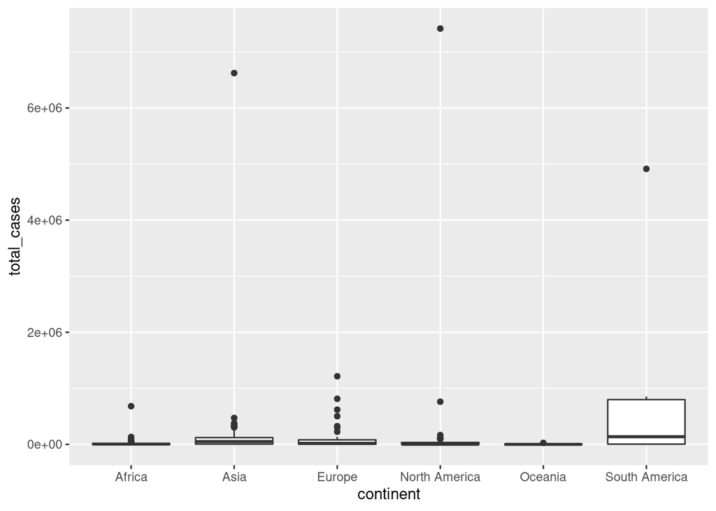

```r
ggplot(data = covid_final_date, mapping = aes(x = continent ,
                                              y = total_cases)) +
  geom_boxplot()
```

```r
covid_stringency <- covid_final_date %>%
  filter(!is.na(stringency_index)) %>%
  arrange(desc(stringency_index)) %>%
  select(stringency_index, location) %>%
  print(covid_stringency)
```

```
## # A tibble: 82 x 2
##    stringency_index location
##               <dbl> <chr>
##  1             87.0 Panama
##  2             86.1 Eritrea
##  3             82.4 Palestine
##  4             81.5 Paraguay
##  5             81.0 Myanmar
##  6             80.6 Trinidad and Tobago
##  7             80.1 Bangladesh
##  8             76.8 Nepal
##  9             75.9 Dominican Republic
## 10             75.9 Gambia
## # … with 72 more rows
```

```r
# US Stringency Index is 66
```

### TO-DO

1. Create categorical variables (GDP, Stringency, Etc.)
2. Figure out which variables have the most impact on Stringency index, cases per capita, cases per death, etc.

Manny and Frankie: H_2

Alex and Parker: H_1 and H_3

H_1: We hypothesize that cases per capita will have a strong negative correlation to stringency index.

H_2: We hypothesize that deaths per case will be largely determined by the GDP per capita, the number of citizens aged 65+, hospital beds per thousand, the human development index, and columns concerning pre-existing conditions (i.e. diabetes prevalence, cardiovascular death rate, etc).

H_3: We hypothesize that the stringency index is going to vary the most by continent. We expect Europe, Asia, Oceania, and North America to have higher stringency indexes, while Africa and South America will have lower stringency indexes.

### Alex

$H_0$: The true correlation of a country’s stringency index and total cases per capita is zero. There is no correlation. ($\rho$ = 0)

$H_1$: The true correlation of a country’s stringency index and total cases per capita is not zero. There is a negative correlation. ($\rho <$ 0)

$\alpha$: 0.05

```r
covid <- covid %>%
  mutate(total_cases_per_cap = (total_cases/population),
         total_deaths_per_cap = (total_deaths/population))

covid_num <- select_if(covid, is.numeric) # Gets all numeric variables
covid_cat <- select_if(covid, is.character) # Gets all categorical variables
covid_cat$stringency_index = covid$stringency_index

col_names <- colnames(covid_num)
cors <- c(rep(NA, ncol(covid_num)))
for(i in 1:ncol(covid_num)) {
  isolated <- covid_num %>%
    filter(!is.na(stringency_index) & !is.na(covid_num[[i]])) %>%
    select(stringency_index, col_names[i])

  cors[i] <- cor(isolated)[2]
}

correlations <- tibble(cors)
correlations$other_var = col_names
correlations <- correlations %>%
  filter(other_var != "stringency_index")%>%
  arrange(desc(abs(cors)))


correlations
```

```
## # A tibble: 29 x 2
##      cors other_var
##     <dbl> <chr>
##  1 -0.245 aged_70_older
##  2 -0.242 aged_65_older
##  3 -0.225 median_age
##  4 -0.199 gdp_per_capita
##  5 -0.195 female_smokers
##  6 -0.194 human_development_index
##  7 -0.189 hospital_beds_per_thousand
##  8  0.179 new_deaths_smoothed_per_million
##  9  0.178 new_cases_smoothed_per_million
## 10 -0.157 life_expectancy
## # … with 19 more rows
```

```r
# Hypothesis test (H_1)
cor.test(covid$stringency_index, covid$total_cases_per_cap, alternative="less")
```

```
##
##  Pearson's product-moment correlation
##
## data:  covid$stringency_index and covid$total_cases_per_cap
## t = 19.339, df = 40315, p-value = 1
## alternative hypothesis: true correlation is less than 0
## 95 percent confidence interval:
##  -1.0000000  0.1039845
## sample estimates:
##        cor
## 0.09587422
```

Using Central Limit Theorem, we have a t distribution with test statistic t = 19.339 and 40315 degrees of freedom. Because our calculated p-value of 1 is greater than my predetermined $\alpha$ of 0.05, we fail to reject the null hypothesis. There is not enough evidence to suggest any negative correlation between stringency index and total cases per capita.

### Parker

$H_0$: The true mean stringency index of Europe, Asia, Oceania, and North America is equal to the true mean stringency index of Africa and South America

$H_1$: The true mean stringency index of Europe, Asia, Oceania, and North America is greater the true mean stringency index of Africa and South America

We are performing a CLT-based Hypothesis Test at the $\alpha$ = .05 level.

```r
# We hypothesize that the stringency index is going to vary the most by
# continent. We expect Europe, Asia, Oceania, and North America to have higher
# stringency indexes, while Africa and South America will have lower stringency
# indexes.

#Change from covid to covid final date- shouldnt be using all observations
#Could be interesting to note how countries stringency indexes change

covid_continent_str_i <- covid_final_date %>%
  group_by(continent) %>%
  filter(!is.na(stringency_index)) %>%
  count(total_str_index = sum(stringency_index)) %>%
  mutate(avg_str_index = total_str_index/n) %>%
  arrange(desc(avg_str_index)) %>%
  select(continent, avg_str_index) %>%
  print(covid_continent_str_i)
```

```
## # A tibble: 6 x 2
## # Groups:   continent [6]
##   continent     avg_str_index
##   <chr>                 <dbl>
## 1 South America          63.2
## 2 North America          59.7
## 3 Asia                   59.3
## 4 Africa                 53.6
## 5 Oceania                41.7
## 6 Europe                 40.8
```

```r
# covid_continent_str_i_2 <- covid %>%
#   group_by(continent) %>%
#   filter(!is.na(stringency_index)) %>%
#   mutate(avg_str_index = mean(stringency_index)) %>%
#   select(continent, avg_str_index) %>%
#   summarise_all(mean) %>%
#   arrange(desc(avg_str_index))
#   print(covid_continent_str_i_2)


covid_si <- covid_final_date %>%
  filter(!is.na(stringency_index)) %>%
  mutate(grouped_continents = case_when(
    ((continent == "Africa") | (continent == "South America")) ~ "af_sa",
    ((continent == "Europe") | (continent == "Asia") ||
       (continent == "Oceania") || (continent == "North America"))
    ~ "eu_as_oc_na"))

#Group 1
covid_af_sa <- covid_si%>%
  filter(grouped_continents == "af_sa") %>%
  summarise(mean_si = mean(stringency_index)) %>%
  print(covid_af_sa)
```

```
## # A tibble: 1 x 1
##   mean_si
##     <dbl>
## 1    55.2
```

```r
#Group 2
covid_eu_as_oc_na <- covid_si%>%
  filter(grouped_continents == "eu_as_oc_na") %>%
  summarise(mean_si = mean(stringency_index)) %>%
  print(covid_eu_as_oc_na)
```

```
## # A tibble: 1 x 1
##   mean_si
##     <dbl>
## 1    50.9
```

```r
t.test(stringency_index ~ grouped_continents,
       data = covid_si,
       mu = 0,
       var.equal = FALSE,
       alternative = "less",
       conf.level = 0.95)
```

```
##
##  Welch Two Sample t-test
##
## data:  stringency_index by grouped_continents
## t = 1.0942, df = 66.498, p-value = 0.8611
## alternative hypothesis: true difference in means is less than 0
## 95 percent confidence interval:
##      -Inf 11.00219
## sample estimates:
##       mean in group af_sa mean in group eu_as_oc_na
##                  55.23100                  50.87269
```

In looking at the summary statistics for the dataset, it becomes clear our perception of global stringency indexes by continent was misguided, as South America had the highest mean stringency index and Africa had the 4th highest. Thus, the average stringency index of Africa and South America was 55.231, which is greater than the mere 50.87269 of Europe, Asia, Oceania, and North America.

```r
chisq.test(table(covid_final_date$continent, covid_final_date$stringency_index))
```

```
##
##  Pearson's Chi-squared test
##
## data:  table(covid_final_date$continent, covid_final_date$stringency_index)
## X-squared = 322.47, df = 285, p-value = 0.06264
```

While we may have determined that we did not have sufficient evidence to suggest that true mean stringency index of Europe, Asia, Oceania, and North America is greater the true mean stringency index of Africa and South America, we see from the summary statistics that different continents do have different mean stringency indexes. Thus, we would like to determine if continent has a statistically significant effect on stringency index.

$H_0$: Stringency index and continent are independent (have no association). $H_1$: Stringency index and continent are not independent (have an association).

We are performing a Chi-Square Test at the $\alpha$ = .05 level.

We have a chi-square distribution with our test statistic $\chi$^2 = 322.47 and 285 degrees of freedom.

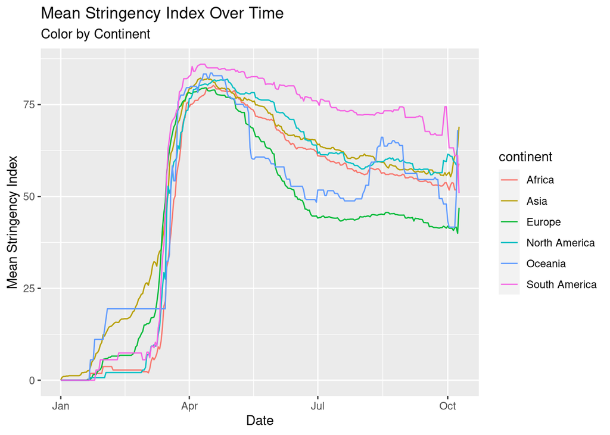

```r
covid_continent_str_i_2 <- covid %>%
  group_by(continent, date) %>%
  filter(!is.na(stringency_index)) %>%
  mutate(avg_str_index = mean(stringency_index))

#Make title more informative
ggplot(data = covid_continent_str_i_2, aes(x=date, y=avg_str_index,
                                           color = continent)) +
  geom_line()+
  labs(x = "Date",
       y = "Mean Stringency Index",
       title = "Mean Stringency Index Over Time",
       subtitle = "Color by Continent")
```

While the past hypothesis tests looked at the final stringency index in our dataset, it may be interesting to see how stringency indexes change over time, and how that may affect cases.

Our visualization highlights similar growth patterns in stringency index among the different continents with a significant rise in March, maximum in April, and slow decline afterward. One can see that Asia and Oceania were quicker to act and increase stringency index, having their stringency indexes around 20 by February (about double the other continents).

### Manny

Hypothesis 2: We hypothesize that deaths per case will be largely determined by the GDP per capita, the number of citizens aged 65+, hospital beds per thousand, the human development index, and columns concerning pre-existing conditions (i.e. diabetes prevalence, cardiovascular death rate, etc).

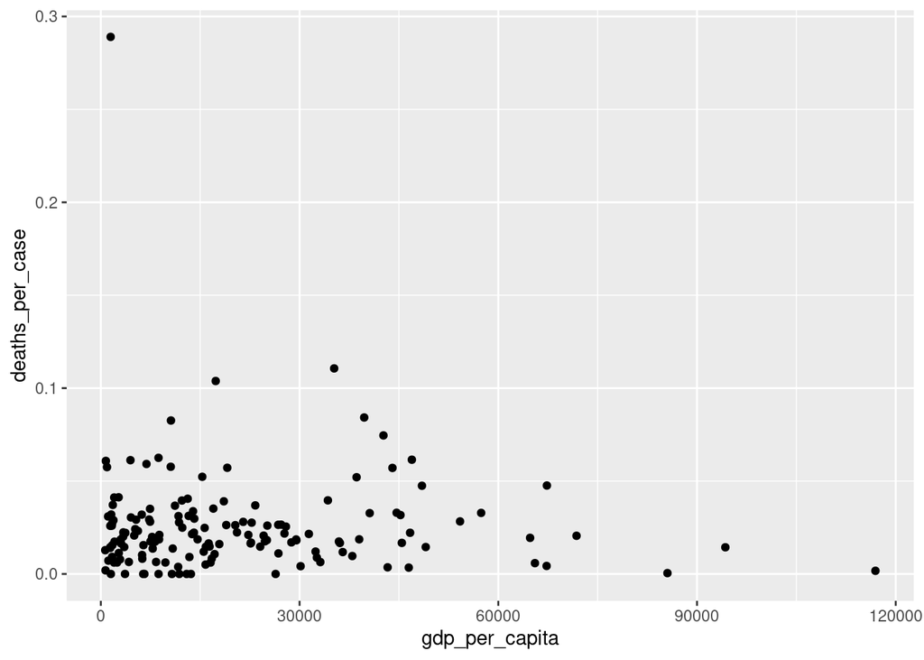

```r
# In order to accurately compare between countries, mutate deaths per case
covid_final_date <- covid_final_date %>%
  mutate(deaths_per_case = total_deaths/total_cases)

# Get rid of null values for numeric variables
filtered_covid <- covid_final_date %>%
  filter(gdp_per_capita > 0) %>%
  filter(aged_65_older > 0) %>%
  filter(hospital_beds_per_thousand > 0) %>%
  filter(human_development_index >0)

ggplot(data = filtered_covid, mapping = aes(x = gdp_per_capita,
                                             y = deaths_per_case)) +
  geom_point()
```

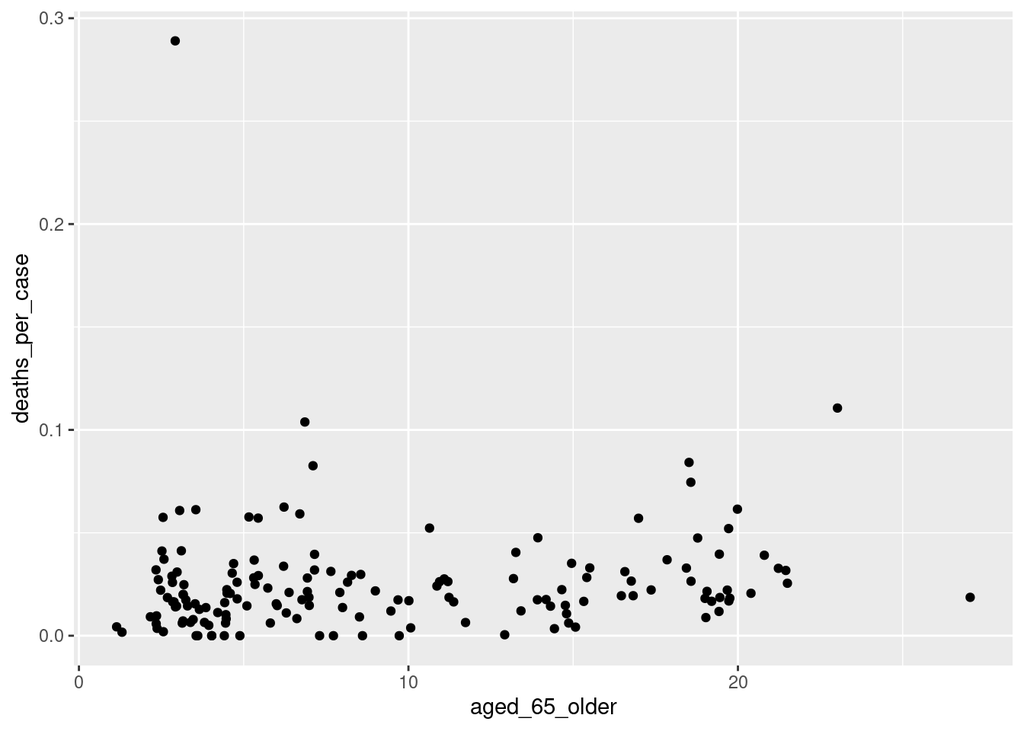

```r
r_gdp <- glance(lm(deaths_per_case ~ gdp_per_capita,
                   data = filtered_covid))$r.squared



ggplot(data = filtered_covid, mapping = aes(x = aged_65_older,
                                             y = deaths_per_case)) +
  geom_point()
```

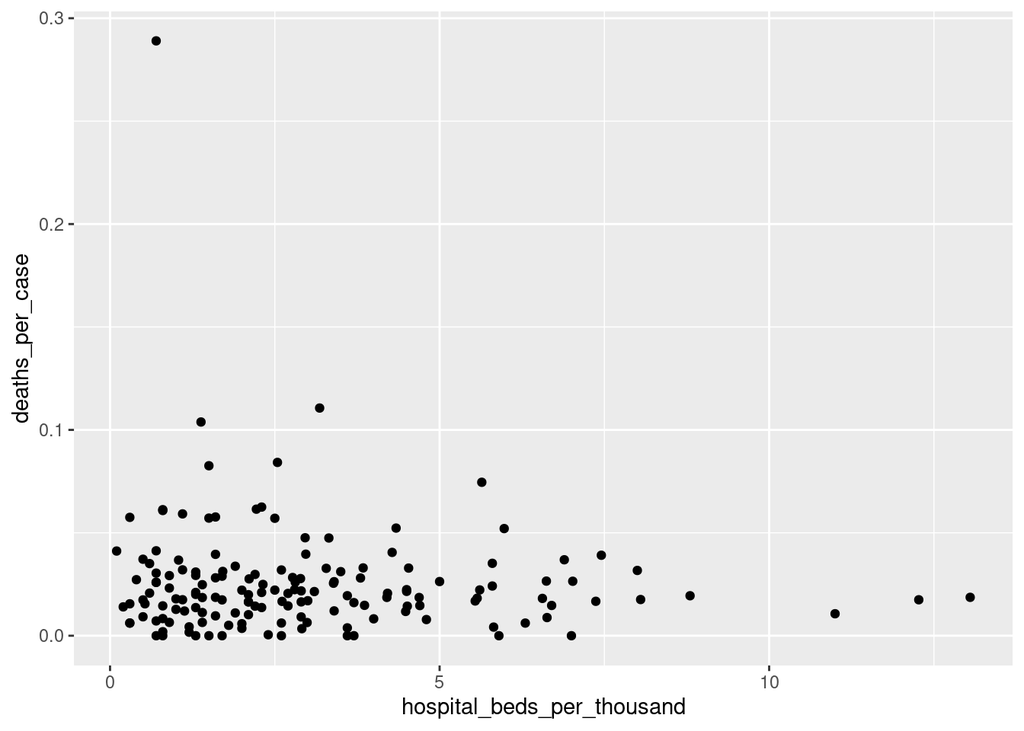

```r
r_seniors <- glance(lm(deaths_per_case ~ aged_65_older,
                       data = filtered_covid))$r.squared



ggplot(data = filtered_covid, mapping = aes(x = hospital_beds_per_thousand,
                                             y = deaths_per_case)) +
  geom_point()
```

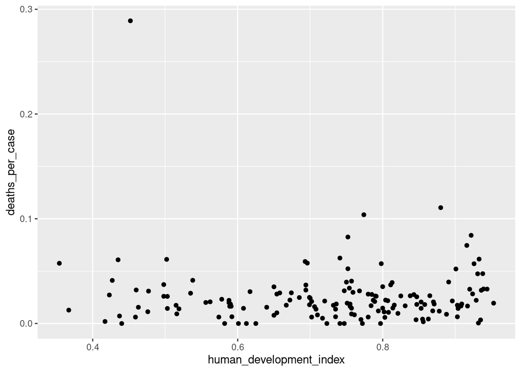

```r
r_hospital <- glance(lm(deaths_per_case ~ hospital_beds_per_thousand,
            data = filtered_covid))$r.squared



ggplot(data = filtered_covid, mapping = aes(x = human_development_index,
                                             y = deaths_per_case)) +
  geom_point()
```

```r
r_dev <- glance(lm(deaths_per_case ~ human_development_index,
            data = filtered_covid))$r.squared

r_gdp
```

```
## [1] 0.00201881
```

```r
r_seniors
```

```
## [1] 0.009554426
```

```r
r_hospital
```

```
## [1] 0.008629651
```

```r
r_dev
```

```
## [1] 0.00164593
```

Given the visualizations between all the continuous numerical variables and deaths per case, as well as the correlations from linear regressions, each of these variables by themselves seems to have little to no impact at all on the deaths per case from COVID. However it very well may be that that the combination between these variables as well as the possibility for interaction terms between them could predict COVID much better.

Hypothesis 2: We hypothesize that deaths per case will be largely determined by the GDP per capita, the number of citizens aged 65+, hospital beds per thousand, the human development index, and columns concerning pre-existing conditions (i.e. diabetes prevalence, cardiovascular death rate, etc).

### Frankie

```r
covid_final_date_deaths <- covid_final_date %>%
  filter(!is.na(total_deaths) & !is.na(total_cases)) %>%
  mutate(deaths_per_case = total_deaths / total_cases)

covid_num <- select_if(covid_final_date_deaths, is.numeric) # Gets all numeric variables
covid_cat <- select_if(covid_final_date_deaths, is.character) # Gets all categorical variables
covid_cat$deaths_per_case = covid_final_date_deaths$deaths_per_case

col_names <- colnames(covid_num)

cors_deaths <- c(rep(NA, ncol(covid_num)))
for(i in 1:ncol(covid_num)) {
  isolated <- covid_num %>%
    filter(!is.na(deaths_per_case) & !is.na(covid_num[[i]])) %>%
    select(deaths_per_case, col_names[i])

  cors_deaths[i] <- cor(isolated)[2]
}

correlations_deaths <- tibble(cors_deaths)
correlations_deaths$other_var = col_names
correlations_deaths <- correlations_deaths %>%
  filter(!str_detect(other_var,'cases') & !str_detect(other_var,'deaths')) %>%
  arrange(desc(abs(cors_deaths))) %>%
  print(correlations_deaths)
```

```
## # A tibble: 16 x 2
##    cors_deaths other_var
##          <dbl> <chr>
##  1   -0.133    male_smokers
##  2   -0.121    diabetes_prevalence
##  3   -0.106    hospital_beds_per_thousand
##  4    0.0942   aged_70_older
##  5   -0.0929   population_density
##  6    0.0876   aged_65_older
##  7    0.0828   population
##  8    0.0661   female_smokers
##  9   -0.0646   extreme_poverty
## 10   -0.0586   stringency_index
## 11   -0.0439   human_development_index
## 12   -0.0213   gdp_per_capita
## 13   -0.0128   life_expectancy
## 14    0.0114   cardiovasc_death_rate
## 15   -0.00327  handwashing_facilities
## 16    0.000137 median_age
```

```r
#str_detect from
#https://stackoverflow.com/questions/22850026/filter-rows-which-contain-a-certain-string

# Hypothesis test (H_1)
# cor.test(covid$stringency_index, covid$total_cases_per_cap, alternative="less")
```

```r
#Could try running a bunch of lines and then seeing which has maximum adjust R^2

m_main <- lm(deaths_per_case ~  hospital_beds_per_thousand + aged_70_older + population_density, data = covid_final_date_deaths)

# m_main %>%
#  tidy() %>%
#  select(term, estimate)

glance(m_main)
```

```
## # A tibble: 1 x 12
##   r.squared adj.r.squared  sigma statistic p.value    df logLik   AIC   BIC
##       <dbl>         <dbl>  <dbl>     <dbl>   <dbl> <dbl>  <dbl> <dbl> <dbl>
## 1    0.0663        0.0479 0.0280      3.62  0.0146     3   341. -672. -656.
## # … with 3 more variables: deviance <dbl>, df.residual <int>, nobs <int>
```

```r
glance(m_main)$r.squared
```

```
## [1] 0.06625504
```

### Draft Report

###Exploratory Data Analysis

```r
covid_final_date <- covid %>%
  filter(date == "2020-10-05" & !is.na(continent)) %>%
  print(covid_final_date)
```

```
## # A tibble: 209 x 41
##    iso_code continent location date       total_cases new_cases new_cases_smoot…
##    <chr>    <chr>     <chr>    <date>           <dbl>     <dbl>            <dbl>
##  1 ABW      North Am… Aruba    2020-10-05        4079         5           33.6
##  2 AFG      Asia      Afghani… 2020-10-05       39341        44           16.3
##  3 AGO      Africa    Angola   2020-10-05        5370       159           99.7
##  4 AIA      North Am… Anguilla 2020-10-05           3         0            0
##  5 ALB      Europe    Albania  2020-10-05       14266       149          144.
##  6 AND      Europe    Andorra  2020-10-05        2110         0           39.1
##  7 ARE      Asia      United … 2020-10-05       98801      1041         1047.
##  8 ARG      South Am… Argenti… 2020-10-05      798473      7668        12452.
##  9 ARM      Asia      Armenia  2020-10-05       52496       571          442.
## 10 ATG      North Am… Antigua… 2020-10-05         107         0            0.857
## # … with 199 more rows, and 34 more variables: total_deaths <dbl>,
## #   new_deaths <dbl>, new_deaths_smoothed <dbl>, total_cases_per_million <dbl>,
## #   new_cases_per_million <dbl>, new_cases_smoothed_per_million <dbl>,
## #   total_deaths_per_million <dbl>, new_deaths_per_million <dbl>,
## #   new_deaths_smoothed_per_million <dbl>, new_tests <lgl>, total_tests <lgl>,
## #   total_tests_per_thousand <lgl>, new_tests_per_thousand <lgl>,
## #   new_tests_smoothed <lgl>, new_tests_smoothed_per_thousand <lgl>,
## #   tests_per_case <lgl>, positive_rate <lgl>, tests_units <lgl>,
## #   stringency_index <dbl>, population <dbl>, population_density <dbl>,
## #   median_age <dbl>, aged_65_older <dbl>, aged_70_older <dbl>,
## #   gdp_per_capita <dbl>, extreme_poverty <dbl>, cardiovasc_death_rate <dbl>,
## #   diabetes_prevalence <dbl>, female_smokers <dbl>, male_smokers <dbl>,
## #   handwashing_facilities <dbl>, hospital_beds_per_thousand <dbl>,
## #   life_expectancy <dbl>, human_development_index <dbl>
```

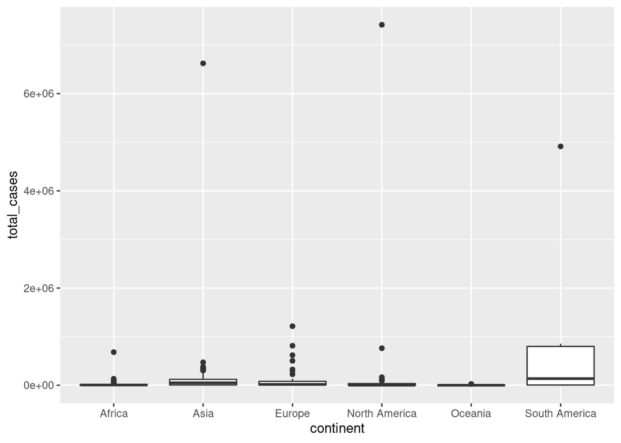

```r
ggplot(data = covid_final_date, mapping = aes(x = continent ,
                                              y = total_cases)) +
  geom_boxplot()
```

```r
covid_stringency <- covid_final_date %>%
  filter(!is.na(stringency_index)) %>%
  arrange(desc(stringency_index)) %>%
  select(stringency_index, location) %>%
  print(covid_stringency)
```

```
## # A tibble: 82 x 2
##    stringency_index location
##               <dbl> <chr>
##  1             87.0 Panama
##  2             86.1 Eritrea
##  3             82.4 Palestine
##  4             81.5 Paraguay
##  5             81.0 Myanmar
##  6             80.6 Trinidad and Tobago
##  7             80.1 Bangladesh
##  8             76.8 Nepal
##  9             75.9 Dominican Republic
## 10             75.9 Gambia
## # … with 72 more rows
```

```r
# US Stringency Index is 66
```

### TO-DO

1. Create categorical variables (GDP, Stringency, Etc.)
2. Figure out which variables have the most impact on Stringency index, cases per capita, cases per death, etc.

Manny and Frankie: H_2

Alex and Parker: H_1 and H_3

H_1: We hypothesize that cases per capita will have a strong negative correlation to stringency index.

H_2: We hypothesize that deaths per case will be largely determined by the GDP per capita, the number of citizens aged 65+, hospital beds per thousand, the human development index, and columns concerning pre-existing conditions (i.e. diabetes prevalence, cardiovascular death rate, etc).

H_3: We hypothesize that the stringency index is going to vary the most by continent. We expect Europe, Asia, Oceania, and North America to have higher stringency indexes, while Africa and South America will have lower stringency indexes.

### Alex

$H_0$: The true correlation of a country’s stringency index and total cases per capita is zero. There is no correlation. ($\rho$ = 0)

$H_1$: The true correlation of a country’s stringency index and total cases per capita is not zero. There is a negative correlation. ($\rho <$ 0)

$\alpha$: 0.05

```r
covid <- covid %>%
  mutate(new_cases_per_cap = (new_cases/population),
         new_deaths_per_cap = (new_deaths/population),
         total_cases_per_cap = (total_cases/population),
         total_deaths_per_cap = (total_deaths/population))

covid_num <- select_if(covid, is.numeric) # Gets all numeric variables
covid_cat <- select_if(covid, is.character) # Gets all categorical variables
covid_cat$stringency_index = covid$stringency_index

col_names <- colnames(covid_num)
cors <- c(rep(NA, ncol(covid_num)))
for(i in 1:ncol(covid_num)) {
  isolated <- covid_num %>%
    filter(!is.na(stringency_index) & !is.na(covid_num[[i]])) %>%
    select(stringency_index, col_names[i])

  cors[i] <- cor(isolated)[2]
}

correlations <- tibble(cors)
correlations$other_var = col_names
correlations <- correlations %>%
  filter(other_var != "stringency_index")%>%
  arrange(desc(abs(cors)))


correlations
```

```
## # A tibble: 31 x 2
##      cors other_var
##     <dbl> <chr>
##  1 -0.245 aged_70_older
##  2 -0.242 aged_65_older
##  3 -0.225 median_age
##  4 -0.199 gdp_per_capita
##  5 -0.195 female_smokers
##  6 -0.194 human_development_index
##  7 -0.189 hospital_beds_per_thousand
##  8  0.179 new_deaths_smoothed_per_million
##  9  0.178 new_cases_smoothed_per_million
## 10 -0.157 life_expectancy
## # … with 21 more rows
```

```r
# Exploration of Hypothesis Test 1
cor.test(covid$stringency_index, covid$new_cases_per_cap, alternative="less")
```

```
##
##  Pearson's product-moment correlation
##
## data:  covid$stringency_index and covid$new_cases_per_cap
## t = 29.683, df = 40315, p-value = 1
## alternative hypothesis: true correlation is less than 0
## 95 percent confidence interval:
##  -1.0000000  0.1542515
## sample estimates:
##       cor
## 0.1462443
```

### Parker

$H_0$: The true mean stringency index of Europe, Asia, Oceania, and North America is equal to the true mean stringency index of Africa and South America

$H_1$: The true mean stringency index of Europe, Asia, Oceania, and North America is greater the true mean stringency index of Africa and South America

We are performing a CLT-based Hypothesis Test at the $\alpha$ = .05 level.

```r
# We hypothesize that the stringency index is going to vary the most by
# continent. We expect Europe, Asia, Oceania, and North America to have higher
# stringency indexes, while Africa and South America will have lower stringency
# indexes.

#Change from covid to covid final date- shouldnt be using all observations
#Could be interesting to note how countries stringency indexes change

covid_continent_str_i <- covid_final_date %>%
  group_by(continent) %>%
  filter(!is.na(stringency_index)) %>%
  count(total_str_index = sum(stringency_index)) %>%
  mutate(avg_str_index = total_str_index/n) %>%
  arrange(desc(avg_str_index)) %>%
  select(continent, avg_str_index) %>%
  print(covid_continent_str_i)
```

```
## # A tibble: 6 x 2
## # Groups:   continent [6]
##   continent     avg_str_index
##   <chr>                 <dbl>
## 1 South America          63.2
## 2 North America          59.7
## 3 Asia                   59.3
## 4 Africa                 53.6
## 5 Oceania                41.7
## 6 Europe                 40.8
```

```r
# covid_continent_str_i_2 <- covid %>%
#   group_by(continent) %>%
#   filter(!is.na(stringency_index)) %>%
#   mutate(avg_str_index = mean(stringency_index)) %>%
#   select(continent, avg_str_index) %>%
#   summarise_all(mean) %>%
#   arrange(desc(avg_str_index))
#   print(covid_continent_str_i_2)


covid_si <- covid_final_date %>%
  filter(!is.na(stringency_index)) %>%
  mutate(grouped_continents = case_when(
    ((continent == "Africa") | (continent == "South America")) ~ "af_sa",
    ((continent == "Europe") | (continent == "Asia") ||
       (continent == "Oceania") || (continent == "North America"))
    ~ "eu_as_oc_na"))

#Group 1
covid_af_sa <- covid_si%>%
  filter(grouped_continents == "af_sa") %>%
  summarise(mean_si = mean(stringency_index)) %>%
  print(covid_af_sa)
```

```
## # A tibble: 1 x 1
##   mean_si
##     <dbl>
## 1    55.2
```

```r
#Group 2
covid_eu_as_oc_na <- covid_si%>%
  filter(grouped_continents == "eu_as_oc_na") %>%
  summarise(mean_si = mean(stringency_index)) %>%
  print(covid_eu_as_oc_na)
```

```
## # A tibble: 1 x 1
##   mean_si
##     <dbl>
## 1    50.9
```

```r
t.test(stringency_index ~ grouped_continents,
       data = covid_si,
       mu = 0,
       var.equal = FALSE,
       alternative = "less",
       conf.level = 0.95)
```

```
##
##  Welch Two Sample t-test
##
## data:  stringency_index by grouped_continents
## t = 1.0942, df = 66.498, p-value = 0.8611
## alternative hypothesis: true difference in means is less than 0
## 95 percent confidence interval:
##      -Inf 11.00219
## sample estimates:
##       mean in group af_sa mean in group eu_as_oc_na
##                  55.23100                  50.87269
```

In looking at the summary statistics for the dataset, it becomes clear our perception of global stringency indexes by continent was misguided, as South America had the highest mean stringency index and Africa had the 4th highest. Thus, the average stringency index of Africa and South America was 55.231, which is greater than the mere 50.87269 of Europe, Asia, Oceania, and North America.

```r
chisq.test(table(covid_final_date$continent, covid_final_date$stringency_index))
```

```
##
##  Pearson's Chi-squared test
##
## data:  table(covid_final_date$continent, covid_final_date$stringency_index)
## X-squared = 322.47, df = 285, p-value = 0.06264
```

While we may have determined that we did not have sufficient evidence to suggest that true mean stringency index of Europe, Asia, Oceania, and North America is greater the true mean stringency index of Africa and South America, we see from the summary statistics that different continents do have different mean stringency indexes. Thus, we would like to determine if continent has a statistically significant effect on stringency index.

$H_0$: Stringency index and continent are independent (have no association). $H_1$: Stringency index and continent are not independent (have an association).

We are performing a Chi-Square Test at the $\alpha$ = .05 level.

We have a chi-square distribution with our test statistic $\chi$^2 = 322.47 and 285 degrees of freedom.

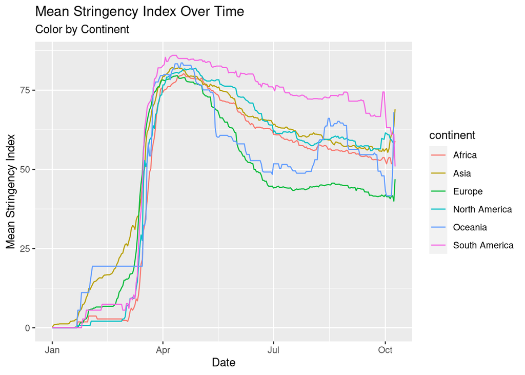

```r
covid_continent_str_i_2 <- covid %>%
  group_by(continent, date) %>%
  filter(!is.na(stringency_index)) %>%
  mutate(avg_str_index = mean(stringency_index))

#Make title more informative
ggplot(data = covid_continent_str_i_2, aes(x=date, y=avg_str_index,
                                           color = continent)) +
  geom_line()+
  labs(x = "Date",
       y = "Mean Stringency Index",
       title = "Mean Stringency Index Over Time",
       subtitle = "Color by Continent")
```

While the past hypothesis tests looked at the final stringency index in our dataset, it may be interesting to see how stringency indexes change over time, and how that may affect cases.

Our visualization highlights similar growth patterns in stringency index among the different continents with a significant rise in March, maximum in April, and slow decline afterward. One can see that Asia and Oceania were quicker to act and increase stringency index, having their stringency indexes around 20 by February (about double the other continents).

We’ve already observed from our correlation tables above that we don’t have enough evidence to suggest there’s a correlation between stringency index and the amount of covid cases. However, we now hypothesize that the reasone we failed to reject our first null hypothesis is that once cases exist, there is little you can do to contain the spread. Thus, we want to assess the possibility that stringency index is correlated to new cases per capita only in the early months of spread.

```r
# Make some sort of variable that tracks a factor by which new cases is growing each day.

n_days <- 90

covid_early <- covid %>%
  group_by(location) %>%
  filter(total_cases > 0 & !is.na(stringency_index) & !is.na(new_cases)) %>%
  slice(1:n_days) %>%
  select(continent, location, total_cases, new_cases, stringency_index)

covid_early
```

```
## # A tibble: 16,110 x 5
## # Groups:   location [179]
##    continent location    total_cases new_cases stringency_index
##    <chr>     <chr>             <dbl>     <dbl>            <dbl>
##  1 Asia      Afghanistan           1         1             8.33
##  2 Asia      Afghanistan           1         0             8.33
##  3 Asia      Afghanistan           1         0             8.33
##  4 Asia      Afghanistan           1         0             8.33
##  5 Asia      Afghanistan           1         0             8.33
##  6 Asia      Afghanistan           1         0            27.8
##  7 Asia      Afghanistan           1         0            27.8
##  8 Asia      Afghanistan           4         3            27.8
##  9 Asia      Afghanistan           7         3            27.8
## 10 Asia      Afghanistan          10         3            38.9
## # … with 16,100 more rows
```

```r
covid_early %>%
  summarize(cor_var_string = cor(stringency_index, new_cases))
```

```
## # A tibble: 179 x 2
##    location    cor_var_string
##    <chr>                <dbl>
##  1 Afghanistan         0.456
##  2 Albania             0.274
##  3 Algeria             0.674
##  4 Andorra            -0.0499
##  5 Angola             -0.0164
##  6 Anguilla            0.105
##  7 Argentina           0.245
##  8 Aruba               0.153
##  9 Australia           0.572
## 10 Austria             0.539
## # … with 169 more rows
```

### Manny

Hypothesis 2: We hypothesize that deaths per case will be largely determined by the GDP per capita, the number of citizens aged 65+, hospital beds per thousand, the human development index, and columns concerning pre-existing conditions (i.e. diabetes prevalence, cardiovascular death rate, etc).

### Frankie

```r
covid_final_date_deaths <- covid_final_date %>%
  filter(!is.na(total_deaths) & !is.na(total_cases)) %>%
  mutate(deaths_per_case = total_deaths / total_cases)

covid_num <- select_if(covid_final_date_deaths, is.numeric) # Gets all numeric variables
covid_cat <- select_if(covid_final_date_deaths, is.character) # Gets all categorical variables
covid_cat$deaths_per_case = covid_final_date_deaths$deaths_per_case

col_names <- colnames(covid_num)

cors_deaths <- c(rep(NA, ncol(covid_num)))
for(i in 1:ncol(covid_num)) {
  isolated <- covid_num %>%
    filter(!is.na(deaths_per_case) & !is.na(covid_num[[i]])) %>%
    select(deaths_per_case, col_names[i])

  cors_deaths[i] <- cor(isolated)[2]
}

correlations_deaths <- tibble(cors_deaths)
correlations_deaths$other_var = col_names
correlations_deaths <- correlations_deaths %>%
  filter(!str_detect(other_var,'cases') & !str_detect(other_var,'deaths')) %>%
  arrange(desc(abs(cors_deaths))) %>%
  print(correlations_deaths)
```

```
## # A tibble: 16 x 2
##    cors_deaths other_var
##          <dbl> <chr>
##  1   -0.133    male_smokers
##  2   -0.121    diabetes_prevalence
##  3   -0.106    hospital_beds_per_thousand
##  4    0.0942   aged_70_older
##  5   -0.0929   population_density
##  6    0.0876   aged_65_older
##  7    0.0828   population
##  8    0.0661   female_smokers
##  9   -0.0646   extreme_poverty
## 10   -0.0586   stringency_index
## 11   -0.0439   human_development_index
## 12   -0.0213   gdp_per_capita
## 13   -0.0128   life_expectancy
## 14    0.0114   cardiovasc_death_rate
## 15   -0.00327  handwashing_facilities
## 16    0.000137 median_age
```

```r
#str_detect from
#https://stackoverflow.com/questions/22850026/filter-rows-which-contain-a-certain-string

# Hypothesis test (H_1)
# cor.test(covid$stringency_index, covid$total_cases_per_cap, alternative="less")
```

Variables with strongest correlation: male_smokers, diabetes_prevalence, hospital_beds_per_thousand, aged_70_older, population_density

gdp_per_capita, human_development_index, cardiovasc_death_rate had lower correlations than we expected

```r
#Could try running a bunch of lines and then seeing which has maximum adjust R^2

m_main <- lm(deaths_per_case ~  hospital_beds_per_thousand + aged_70_older + population_density, data = covid_final_date_deaths)

# m_main %>%
#  tidy() %>%
#  select(term, estimate)

glance(m_main)
```

```
## # A tibble: 1 x 12
##   r.squared adj.r.squared  sigma statistic p.value    df logLik   AIC   BIC
##       <dbl>         <dbl>  <dbl>     <dbl>   <dbl> <dbl>  <dbl> <dbl> <dbl>
## 1    0.0663        0.0479 0.0280      3.62  0.0146     3   341. -672. -656.
## # … with 3 more variables: deviance <dbl>, df.residual <int>, nobs <int>
```

```r
glance(m_main)$r.squared
```

```
## [1] 0.06625504
```